# How Trends Differ By News Sites

Elise Wilson

## Introduction

For this project, I was interested in looking at different trends on various news websites. I settled on comparing Politico, The New York Times, FOX News, and The Washington Post. On one particular day, I randomly chose 25 articles from each news site that were on the front page, and noted the number of pictures and comments that corresponded to each article. I have three hypotheses relating to my data. Firstly, I think that FOX News will have the most comments on their articles, as FOX is commonly known to be highly controversial. Secondly, the New York Times will most likely provide the most pictures to accompany their articles as this site is a particularly well known and acclaimed site and they probably will strive to make their articles visually appealing to the readers. Thirdly, as the number of pictures goes up, I hypothesize that the number of comments will also rise due to the fact that “a picture speaks a thousand words,” and many people are moved by pictures in ways that words do not move them.

## Methods

To collect my data, I chose the four of the biggest news outlets in the country: the New York Times, the Washington Post, CNN, and FOX News. Unfortunately, I could not find any comment section on CNN, so I switched out that news site for Politico. I then went through and clicked on 25 random articles on each site that were linked to the home page, and collected data on the number of pictures and comments associated with each article. After collecting my data, I then input and analyzed the data into regression tables and graphics, which can be seen in the following sections.

## Results

The results of the data collection are as follows, shown through the use of regression tables and graphics.

```
##
## Call:
## lm_basic(formula = comments ~ 1 + site, data = newsdata)
##
## Residuals:
##     Min      1Q  Median      3Q     Max
## -1585.4  -603.6   -96.8    23.6  6421.6
##
## Coefficients:
##                     Estimate   2.5 % 97.5 %
## (Intercept)           1585.4  1048.8 2122.0
## siteNew York Times   -1481.6 -2240.5 -722.7
## sitePolitico         -1529.8 -2288.7 -770.9
## siteWashington Post   -960.3 -1719.2 -201.4
##
## Residual standard error: 1352 on 96 degrees of freedom
## Multiple R-squared:  0.1775, Adjusted R-squared:  0.1518
## F-statistic: 6.905 on 3 and 96 DF,  p-value: 0.0002933
```

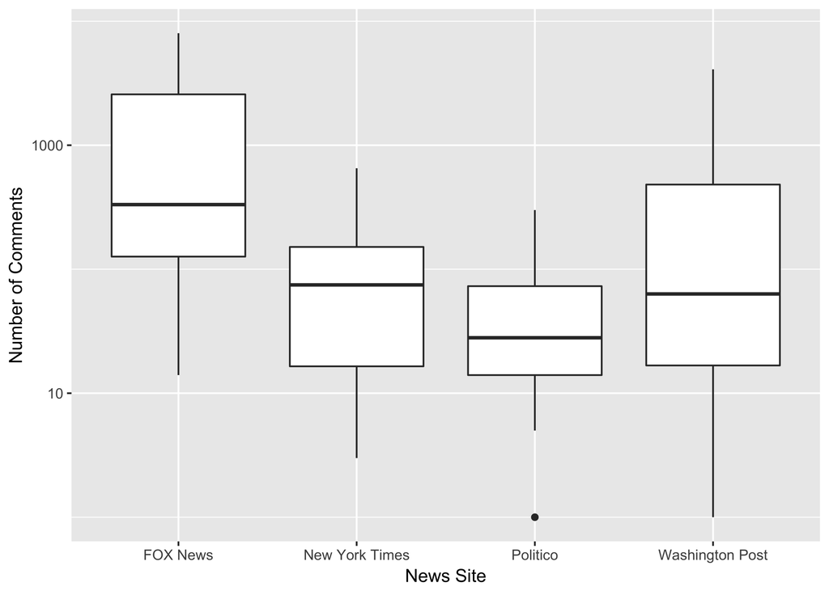

According to the above plot, the mean number of comments posted to the articles on FOX News are statistically significantly higher than the mean of the comments posted to the articles published on the other three sites.

```
##
## Call:
## lm_basic(formula = photos ~ 1 + site, data = newsdata)
##
## Residuals:
##    Min     1Q Median     3Q    Max
##  -2.16  -1.04  -0.08   0.16  12.84
##
## Coefficients:
##                     Estimate   2.5 % 97.5 %
## (Intercept)           2.8400  2.0696   3.61
## siteNew York Times    0.3200 -0.7695   1.41
## sitePolitico         -1.7600 -2.8495  -0.67
## siteWashington Post  -0.8000 -1.8895   0.29
##
## Residual standard error: 1.941 on 96 degrees of freedom
## Multiple R-squared:  0.1517, Adjusted R-squared:  0.1252
## F-statistic: 5.722 on 3 and 96 DF,  p-value: 0.001204
```

This second regression table, seen above, again shows the intercept as FOX News. This data output shows that while the mean number of pictures is highest for the New York Times, the difference is not statistically significant.

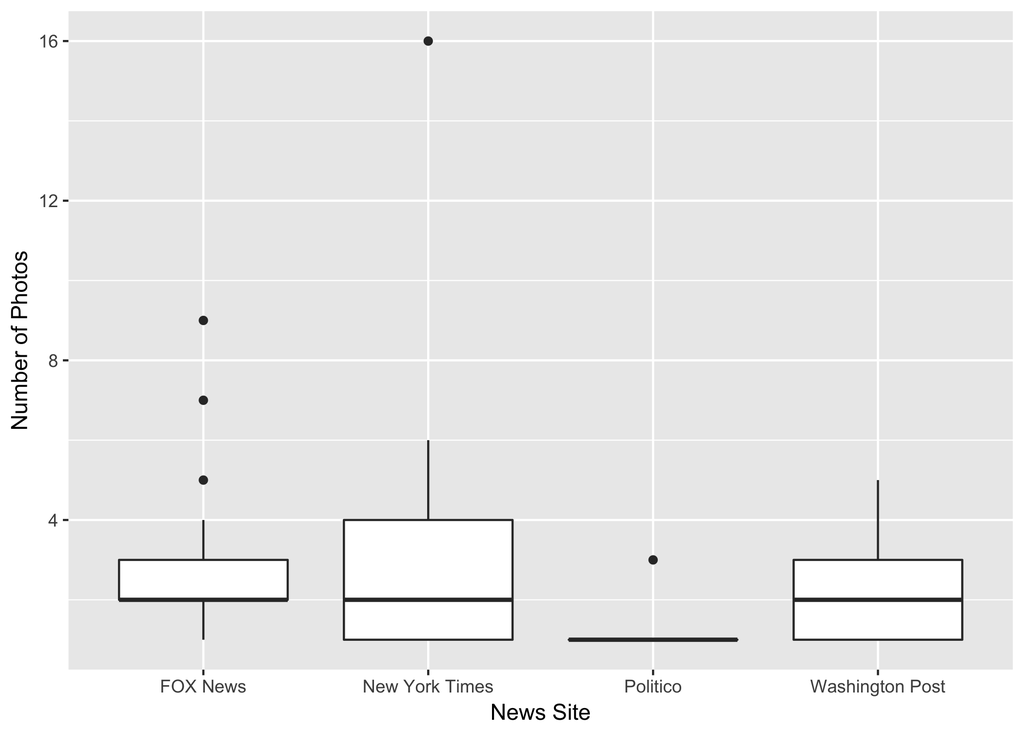

As can be see in the graph above, the mean number of photos associated with articles published on the New York Times website are higher than the number of photos posted on the other sites, but the difference is not statistically significantly higher.

```
##
## Call:
## lm_basic(formula = comments ~ 1 + photos, data = newsdata)
##
## Residuals:
##     Min      1Q  Median      3Q     Max
## -1568.8  -534.3  -476.1  -300.1  7434.5
##
## Coefficients:
##             Estimate   2.5 % 97.5 %
## (Intercept)  429.749  -4.176  863.7
## photos        71.378 -69.704  212.5
##
## Residual standard error: 1468 on 98 degrees of freedom
## Multiple R-squared:  0.01018,    Adjusted R-squared:  8.112e-05
## F-statistic: 1.008 on 1 and 98 DF,  p-value: 0.3178
```

Above is the final regression table showing the relationship between photos and comments. The data shows that while there is a positive correlation between the two variables (when one goes up, so does the other), this trend is not statistically significant.

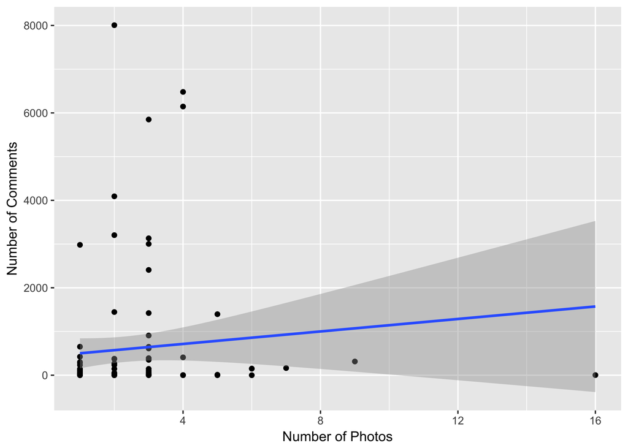

The graph above shows that as the number of photos on a news site increases, so does the number of comments associated with those articles, though the positive difference is not statistically significantly higher.

## References

“Breaking News, World News & Multimedia.” The New York Times, The New York Times, www.nytimes.com/.

“Fox News.” Fox News, FOX News Network, www.foxnews.com/.

POLITICO, www.politico.com/.

“Washington Post: Breaking News, World, US, DC News & Analysis.” The Washington Post, WP Company, www.washingtonpost.com/.